# Bay Wheels Bike Sharing System Usage Pattern

## by Yash Ahuja

## Investigation Overview

> Bay Wheels is a public bicycle sharing system in the San Francisco Bay Area, California. I'm most interested in exploring the bike trips' duration and rental events occurrance patterns in terms of time of day, day of the week, along with how these relate to the riders' characteristics, i.e. their user type, gender, age, etc. to get a sense of what and how people are using the bike sharing service for.

## Dataset Overview

> The dataset consists of approx. 180,000+ bike trips that happened in Feb 2019 covering the San Francisco Bay Area. The data can be downloaded from [here](https://s3.amazonaws.com/baywheels-data/index.html). The dataset contains features regarding trip duration, station information and annonymized member information (user type, gender etc). Visualizations are created from wrangled and cleaned data to facilitate exploration analysis and help discover usage pattern and rider characteristics.

## Distribution of Trip Duration

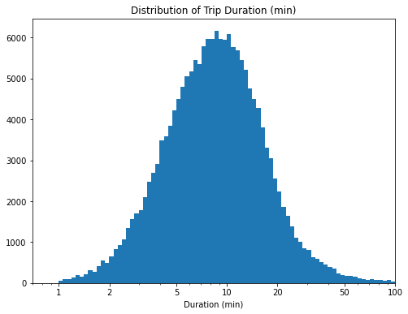

## Distribution of Member Age

Average member age is 34 years. The distribution of age was also positively skewed with some outliers at the end but instead of log scaling at first, we tried to limit the range to check if we can find any pattern. Based on the histogram plot, we chose 70 years as the upper bound to analyse the pattern by focusing on the most common trips. After setting 70 years as the upper bound, the trend was clearly visible, with age still following a positively skewed distribution having more than two thirds of the trips have customers or subscribers having age 25-40 years implicating that majority of the users are middle aged adults.

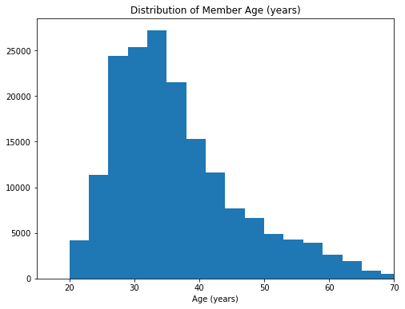

## Trip Duration & Age of riders across different days of the week

- On average, bike rides on weekends (Sat-Sun) have longer durations as compared to bike rides on other weekdays (Mon-Fri).
- On average, bikers on weekdays (Mon-Fri) are older than bikers on weekends (Sat-Sun).

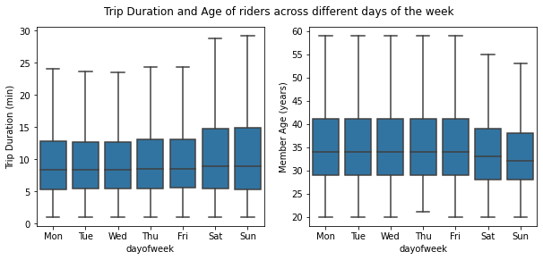

## Trip Duration & Age of riders across different user & gender types

- On average, users who are 'Customer' have longer bike trip durations as compared to users who are 'Subscriber'.
- On average, female bikers have longer bike trip durations as compared to male bikers.
- The average age of male bikers is higher than that of female bikers.
- The average age of 'Subscriber' and 'Customer' type bikers is approximately same. However, Subscriber user type has more older people compared to customer user type and the same goes for male users over female users.

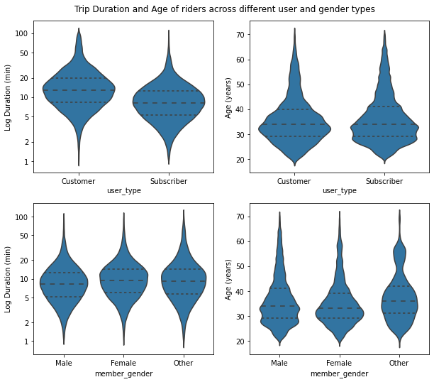

## Daily and Weekly Bike Trip Trends of different user types

- Thursday, 8 AM and 5 PM has the highest bike trips across 7 days and 24 hours.
- Overall, weekdays have higher number of trips than weekends except two time frames:
  1. 10 AM - 3 PM (the usual office hours) in which both have approx. same number of trips.
  2. 12 midnight to 2 AM in which weekends have more trips than weekdays.
- Overall, Subscribers have higher number of trips than customers across all times of the day. Moreover, 8 AM and 5 PM has the most 'Subscriber' bikers compared to other hours. Also, 5 PM has the most 'Customer' bikers compared to other times of the day.
- Overall, Subscribers have higher number of trips than customers across all days of the week. Moreover, Thursday has the most 'Subscriber' and 'Customer' bikers compared to other days.

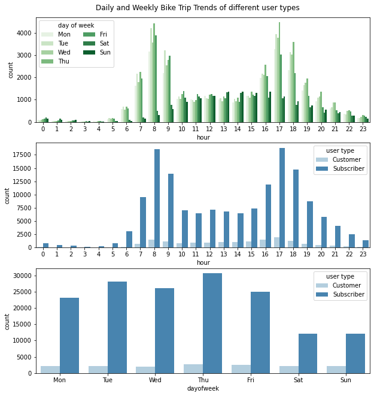

## Daily and Weekly Bike Trip Trends of different gender types

- Overall, male bikers have higher number of trips as compared to female and other gender type across all the times of the day (hour) and days of the week.
- Most of the Subscriber bikers are male. Most of the Customer bikers are also male.
- 8 AM and 5 PM has the highest male and female bikers across 24 hours
- Thursday has the most male bikers compared to other days. It also has the most female bikers compared to other days.

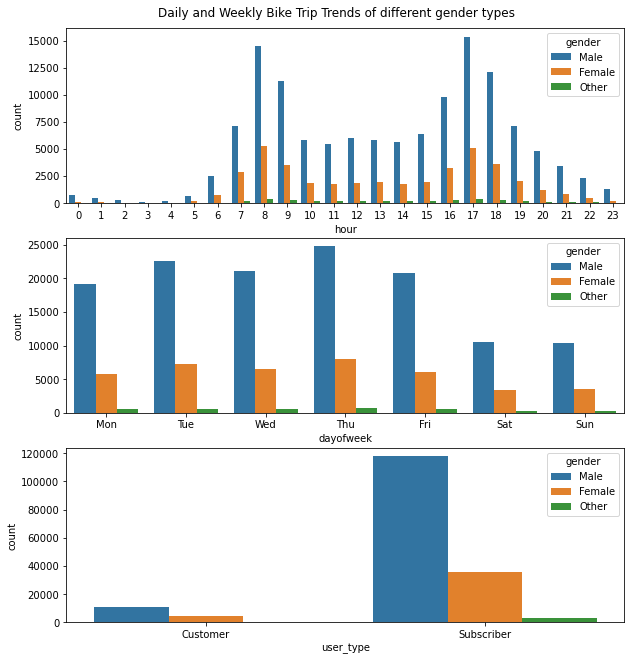

## Daily and Weekly Average Bike Trip Duration of different user and gender types

- Customers have higher average bike trip duration than subscribers across all the times of the day (hour) and days of the week with customers having higher average bike trip duration on weekends (Sat-Sun) as compared to weekdays (Mon-Fri) and the same could not be said for subsribers as their difference between weekdays and weekends in terms of average bike trip durations is not significant.
- Female bikers have higher average bike trip duration than male bikers across all the days of the week with female bikers having higher average bike trip duration on weekends (Sat-Sun) as compared to weekdays (Mon-Fri) and same goes for male bikers.

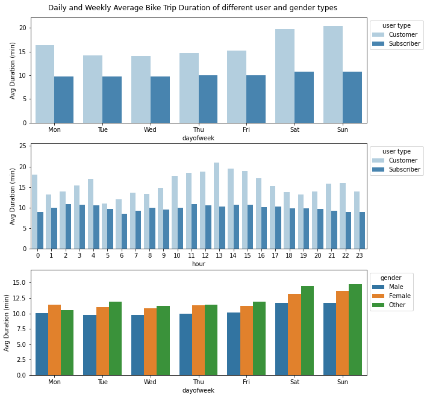

## Combining all the usage patterns together for Customers and Subscribers

- A very different usage pattern is observed between the two type of bike riders. Subscribers use the bike sharing system heavily on work days i.e. Monday through Friday whereas customers ride a lot on weekends i.e. Saturday and Sunday, especially in the afternoon. Many trips are concentrated around 8-9 AM and 4-6 PM on work days for subscribers who probably use the system for work commute, yet customers tend to use more in the late afternoon around 5 PM on weekdays (Monday to Friday). Other than usage purpose and habit, traffic situation around these rush hours in the area may also have an influence in this trend.
- The efficient/short period of usage for subscribers, involving more older people as compared to customer bikers, corresponds to their high concentration on rush hours Monday through Friday, indicating that they use the system heavily on weekdays, compared to customer bikers, primarily for work commute. Whereas, customer bikers who have more younger people as compared to the subscribers have more relaxing and flexible usage pattern. It is supported by the fact that they're taking advantage of the bike sharing system quite differently from the subscribers as they use the system heavily on weekends (especially in the afternoon) compared to subscribers for city tour or leisure purpose probably which will be investigated further.

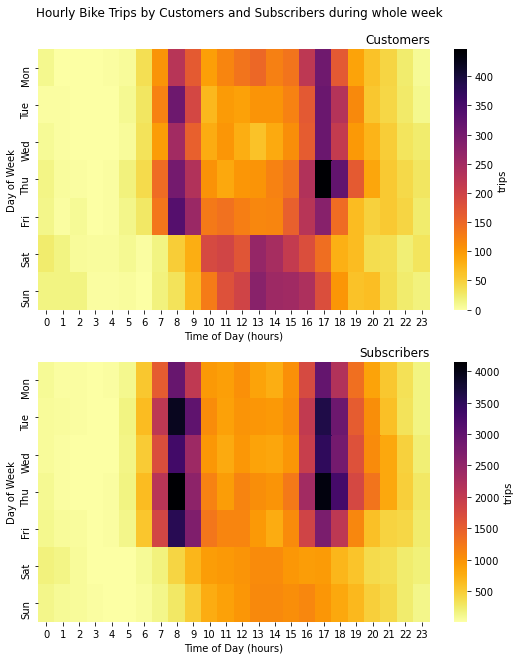

## Digging further...

### Analyzing the Average Bike Trip duration of Customers and Subscribers for different age groups:

*Middle aged adults (20-40 years) and Adults (more than 40)*

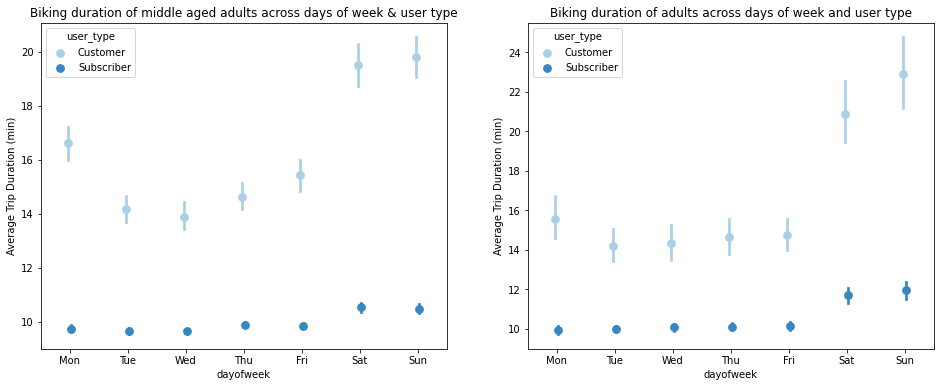